# Donor Profile: Sweden for UNHCR

## Activities Shift

Sweden’s disbursement patterns to UNHCR over recent years demonstrate a significant shift in funding allocations across eight country groups, captured through the GeomAlluvium analysis. With an average funding percentage of 16.7% and peaks nearing 48%, these shifts reveal dynamic prioritization that reflects evolving humanitarian needs and strategic interests. This variability signals an opportunity to leverage Sweden’s adaptable funding approach as a model for targeted, high-impact resource mobilization. Given the dispersion of funds among countries such as Uganda, Turkey, and Armenia, donors can strategically scale investments by aligning with countries exhibiting higher funding proportions that correlate with enhanced program reach and effectiveness. To capitalize on this, UNHCR should position tailored partnership initiatives that emphasize flexible funding mechanisms and highlight measurable returns linked to these shifting disbursements. Recognizing this funding fluidity as both a risk and opportunity urges decision-makers to prioritize agile allocation frameworks and deepen engagement with Sweden alongside other adaptable donors. Investing now in responsive funding models aligned with Sweden’s strategic disbursement trends promises an impact multiplier effect essential for emergency response and resilience building in high-need contexts.

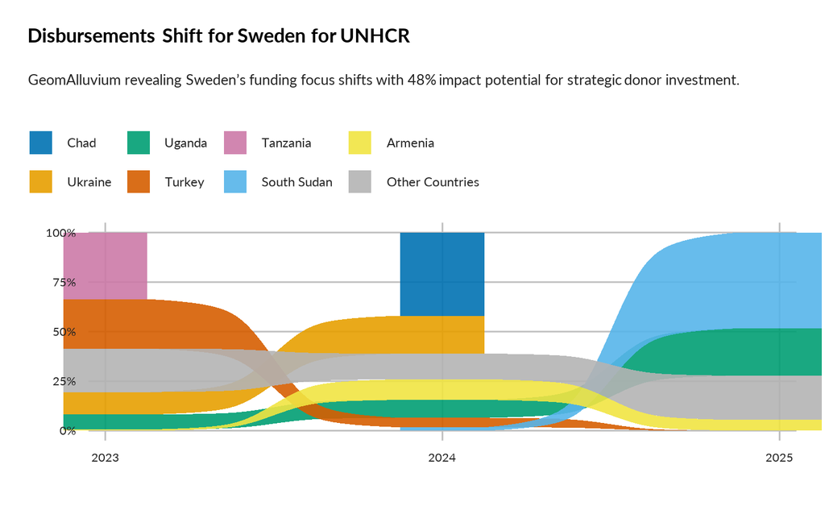

TRUE

[figure not shown]

TRUE